# Binomial_Data

Many statistical problems involve binary response variables. For example, we could classify individuals as alive/dead, healthy/unwell, employ/unemployed, left/right, right/wrong, … etc. A regression of binary data is possible if at least one of the predictors is continuous (otherwise you would use some kind of categorical test, such as a Chi-squared test).

The response variable contains only 0s and 1s (e.g., dead = 0, alive = 1) in a single vector. R treats such binary data is if each row came from a binomial trial with sample size 1. If the probability that an individual is dead is *p*, then the probability of obtaining *y* (where *y* is either dead or alive, 0 or 1) is given by an abbreviated form of the binomial distribution with n = 1, known as the Bernoulli distribution.

Binomial data can either be modelled at the individual (binary response) or group (proportion) level. If you have unique values of one or more explanatory variables for each and every individual case, then a model with a binary response variable will work. If not, you should aggregate the data until you do have such explanatory variables (e.g., at the level of the household, town, state, population, …).

# A. Individual-level: binary response (0/1) = **logistic regression**

At the individual level we can model each individual in terms of dead or alive (male/female, tall/short, green/red, …), using logistic regression (or logit model). In the [logit](https://en.wikipedia.org/wiki/Logit) model, the **log odds** (logarithm of the odds) of the outcome is modeled as a linear combination of the predictor variables. If *p* is a probability, then *p/(1 − p)* is the corresponding odds; the logit of the probability is the logarithm of the odds.

To model a binary response variable, we first need (or need to create) a single vector of 0 and 1s. We then model this vector with `glm()` and `family = 'binomial'`. We can compare models using a test for a change in deviance with chi-squared. Overdispersion is not an issue with a binary response variable.

Let’s look at the incidence (presence/absence) of a breeding bird on various islands. Examine the top 6 rows of the isolation dataset.

```r
head(isolation)
```

```
##   incidence  area distance
## 1         1 7.928    3.317
## 2         0 1.925    7.554
## 3         1 2.045    5.883
## 4         0 4.781    5.932
## 5         0 1.536    5.308
## 6         1 7.369    4.934
```

The data show the `$incidence` of the bird (present = 1, absent = 0) on islands of different sizes (`$area` in km2) and distance (`$distance` in km) from the mainland.

We can easily imagine how we might be more likely to find a specific bird on larger islands that are closer to the mainland, and less likely to find that bird on smaller islands further away from the mainland.

Now let’s plot the data. First, plot `incidence` as a function of `distance`.

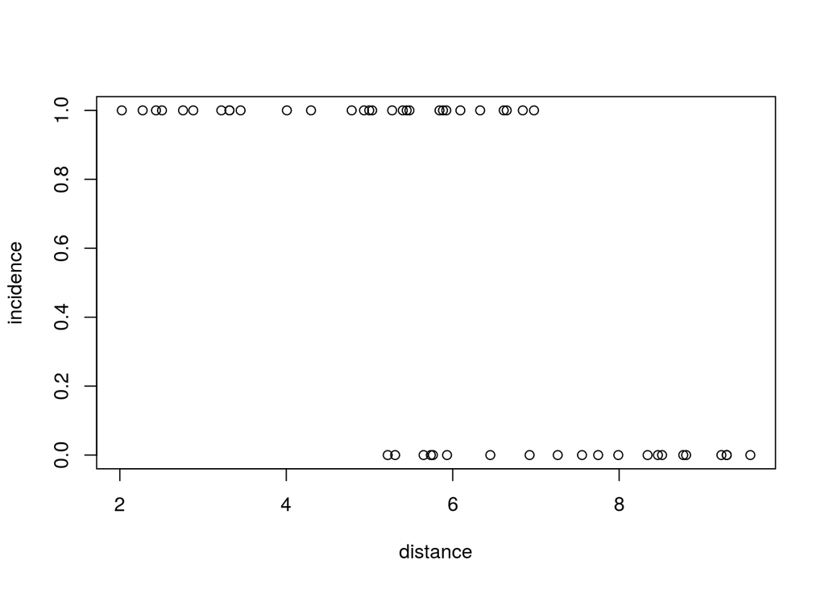

```r
plot(incidence ~ distance, data = isolation)
```

Because we only have two options for the y-axis (response variable), 0 or 1, we have two lines of data points at different distances (x-axis). It looks like there are more 1’s than 0’s at lower values of distance and fewer 1’s than 0’s at higher values of distance.

Now make a similar plot where `area` is our predictor.

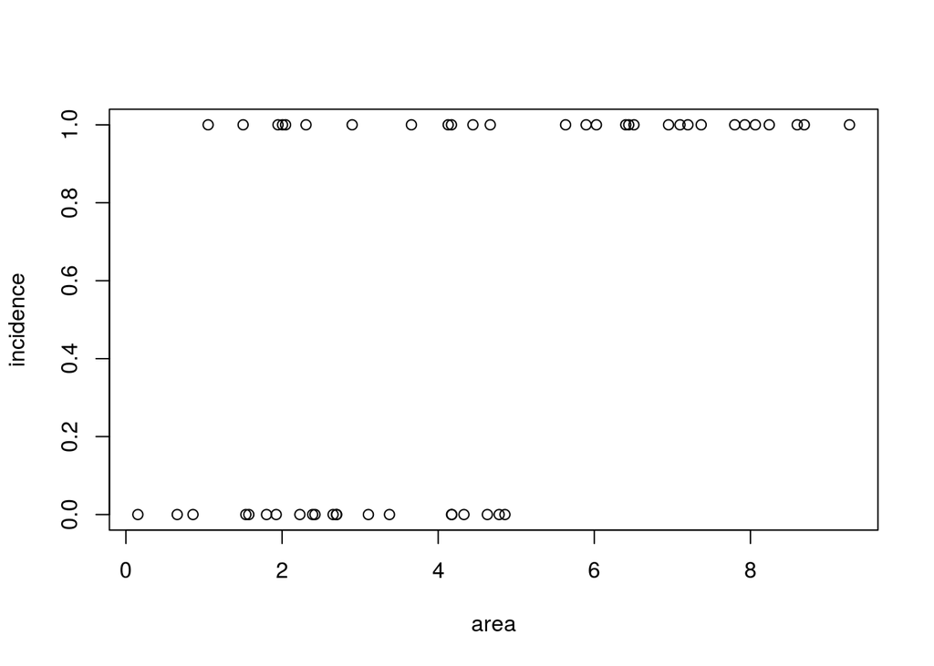

```r
plot(incidence ~ area, data = isolation)
```

You can see that area has the opposite effect: as area increases, we see fewer 0’s and more 1’s. Let’s test these relationships using a generalized linear model.

We can begin examining these patterns in more detail by fitting a model of incidence as a function of area and distance. We will first consider the additive model (i.e., area and distance are independent).

To do this, we’ll need to run a more flexible form of a linear model, called a generalized linear model. Simply, this lets us fit a linear model with error terms from other, non-normal distributions. In this case, we assume our binomial response has errors following a bernoulli distribution.

Use `glm()`, which stands for generalized linear model, and call it `m0`. Use a formula, set the `data =` argument, *and* the `family = binomial` argument.

```r
m0 <- glm(incidence ~ area + distance, family = binomial, data = isolation)
```

What are we actually stating in this additive model? We are saying that area and distance have the same effect on incidence, but that the intercept may be different between them. If we plotted both on the same graph, they would have the same slope, but maybe different intercepts.

Ok, what if we think that there is an interaction between area and distance, i.e., the slope of each variable varies as well as the intercept? Run the model of an interaction between area and distance, called `m1`.

```r
m1 <- glm(incidence ~ area * distance, family = binomial, data = isolation)
```

We can compare these two models using ANOVA. The function `anova()` computes analysis of variance (or deviance) tables for one or more fitted model objects. Run this function on `m0` and `m1`. In the case of binary data, we need to do a Chi-squared test (`test = 'Chi'`).

```r
anova(m0, m1, test = "Chi")
```

```
## Analysis of Deviance Table
##
## Model 1: incidence ~ area + distance
## Model 2: incidence ~ area * distance
##   Resid. Df Resid. Dev Df Deviance Pr(>Chi)
## 1        47     28.402
## 2        46     28.252  1  0.15043   0.6981
```

The simpler model (m0) is not significantly worse (p = 0.6981), so we can go with that one.

## Fitting and interpreting the model

Let’s look at the summary of model `m0`.

```r
summary(m0)
```

```
##
## Call:
## glm(formula = incidence ~ area + distance, family = binomial,
##     data = isolation)
##
## Deviance Residuals:
##     Min       1Q   Median       3Q      Max
## -1.8189  -0.3089   0.0490   0.3635   2.1192
##
## Coefficients:
##             Estimate Std. Error z value Pr(>|z|)
## (Intercept)   6.6417     2.9218   2.273  0.02302 *
## area          0.5807     0.2478   2.344  0.01909 *
## distance     -1.3719     0.4769  -2.877  0.00401 **
## ---
## Signif. codes:  0 '***' 0.001 '**' 0.01 '*' 0.05 '.' 0.1 ' ' 1
##
## (Dispersion parameter for binomial family taken to be 1)
##
##     Null deviance: 68.029  on 49  degrees of freedom
## Residual deviance: 28.402  on 47  degrees of freedom
## AIC: 34.402
##
## Number of Fisher Scoring iterations: 6
```

As normal, we have the formula, the deviance residuals (a measure of model fit), then the coefficient estimates, their standard errors, the z-statistic (sometimes called a Wald z-statistic), and p-values. What exactly do the coefficients represent?

The coefficients as presented in the model summary are the logits. We can then transform these logits to odds ratios if we want.

### Logit/log odds

The logistic regression coefficients give the *change in the log odds* (i.e., the logarithm of the odds, called the *logit*).

For continuous predictors, the coefficients give the *change in the log odds* of the outcome for a one unit increase in the predictor variable. For example, for every 1km^2 increase in area, the log odds of the bird being present (versus absent) increases by 0.58 and the log odds of the bird being present *decreases* by 1.37 (i.e., -1.37) for every km of distance from the mainland.

For categorical predictors, the coefficient estimate describes the change in the log odds for each level compared to the base level.

Confidence intervals around the coefficient estimates can be calculated with the function `confint()`. Calculate the CIs for `m0`.

```r
confint(m0)
```

```
##                  2.5 %    97.5 %
## (Intercept)  1.8390115 13.735103
## area         0.1636582  1.176611
## distance    -2.5953657 -0.639140
```

Logits (log odds) are just one way of describing the model. We can easily convert the logits either to odds ratios or predicted probabilities.

### Odds ratios

[Odds ratios](https://en.wikipedia.org/wiki/Odds_ratio) are a relative measure of effect, which allows the comparison of two groups. It is a popular way of presenting results in medicine, especially of controlled trials. Here, the odds of one group (usually the control) is divided by the odds of another (the treatment) to give a ratio. In this case, if the odds of both groups are the same, the ratio will be 1, suggesting there is no difference. If the OR is > 1 the control is better than the other level. If the OR is < 1 the treatment is better than the control.

However, in R, we are presented with *differences* or the *change* in log odds between groups (for categorical variables) or the change in log odds between *x* and *x + 1* (for continuous variables). The directionality is the opposite to the example above because R effectively compares the ‘treatment’ to the ‘control’.

Thus, for **categorical predictors**, an odds ratio of > 1 suggests a positive difference between levels and the base level (the exponential of a positive number is greater than 1), i.e., the base level has a lower odds and the treatment level has a higher odds. An odds ratio of < 1 suggests a negative difference (the exponential of a negative number lies between 0 and 1).

For **continuous predictors**, the odds ratio is the odds of *x + 1* over *x* (i.e., the odds ratio for a unit increase in the continuous *x* predictor variable), and the interpretation is the same as for categorical.

To obtain these odds ratios in R, we need to exponentiate the coefficient estimates. Remember that these estimates are the log of the odds, so the exponent is the actual odds. The function `exp()` can do this for us.

Remember that we can extract the coefficient estimates from any model with the function `coef()`. Put `exp()` and `coef()` together to obtain the odds ratios from m0.

```r
exp(coef(m0))
```

```
## (Intercept)        area    distance
## 766.3669575   1.7873322   0.2536142
```

Since both our predictors are continuous, they are the odds ratios for x+1 to x. The odds ratio for area is 1.79, indicating that for a 1km^2 increase in area we expect a 79% increase in the odds of finding the bird on the island. For a 1km increase in distance of the island from the mainland, we expect a 75% decrease in the odds of finding the bird.

A more detailed discussion of these different representations can be found here: https://stats.idre.ucla.edu/other/mult-pkg/faq/general/faq-how-do-i-interpret-odds-ratios-in-logistic-regression/

### Predicted probabilities

We can generate predicted probabilities for both continuous and categorical variables. To do this, we call the `predict()` function, which can generate predictions for each row in the original data set.

Setting `type = 'link'` returns the logits; setting `type = 'response'` returns the predicted probabilities.

Add an extra column to the dataset for the predicted logits, called ‘logit’ by using the `predict()` function on m0 and setting the correct type. Remember that to add a column we just need to call the data object, and add the new column name with a dollar sign.

```r
isolation$logit <- predict(m0, type = 'link')
```

Add another column for the predicted probabilities, called ‘p’.

```r
isolation$p <- predict(m0, type = 'response')
```

However, to better plot these relationships, we should input a specific range of x’s that we predict y’s for.

## Plotting binary response data

To plot the fitted line of a generalized linear model, we generally have to use the `predict()` function, because the model, although linear, is not a straight line that can be plotted with either an intercept or slope, as we used for `lm()` and `abline()`.

The function `predict()` is a general wrapper for more specific functions, in this case `predict.glm()`. We have to specify the `object` (i.e., the fitted model), the `newdata` (i.e., the values of `x` for which we want predictions, named identically to the predictors in the object, as a dataframe or list), and the `type` of prediction required (either on the scale of the linear predictors (‘link’) or on the scale of the response variable (‘response’).

There are, as usual, at least two ways we could do this. First, we will make two separate individual logistic regressions and make predictions from those.

Make a logistic model for incidence as a function of area, called `ma`.

```r
ma <- glm(incidence ~ area, family = binomial, data = isolation)
```

We then need to make a sequence of x values (e.g., `$area`) from which to predict the y (predicted probability of `$incidence`). To do this, first generate a sequence of x values from 0 to 9, in steps of 0.1. Call this vector `xv`.

```r
xv <- seq(from = 0, to = 9, by = 0.1)
```

```r
yv <- predict(object = ma, newdata = data.frame(area = xv), type = "response")
```

Now, we have two vectors, xv and yv, that we can use to plot the fitted (predicted) line.

Add this fitted line to the plot of incidence on area, using the `lines()` function.

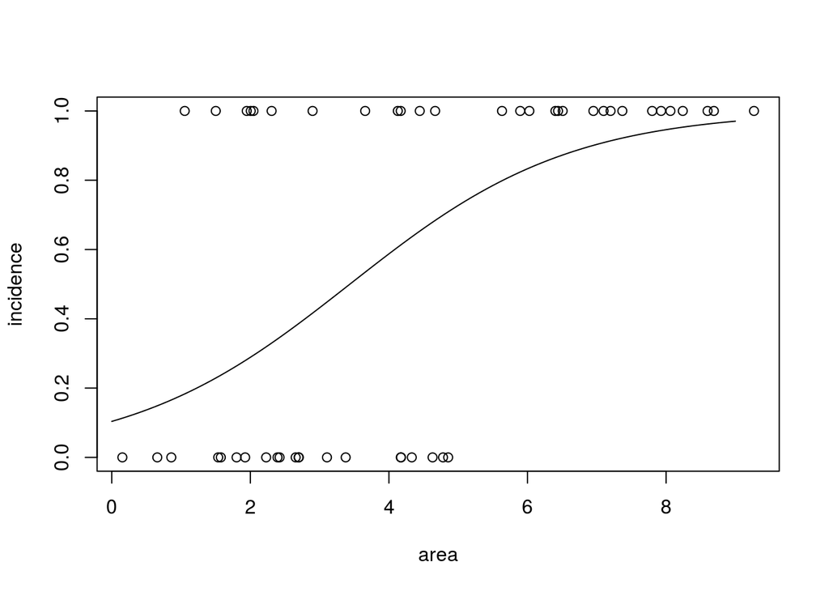

```r
plot(incidence ~ area, data = isolation)
lines(xv, yv)
```

Now let’s repeat this process for distance. First, make the model using `glm()` and call it `md`.

```r
md <- glm(incidence ~ distance, family = binomial, data = isolation)
```

```r
xv <- seq(from = 0, to = 9, by = 0.1)
```

```r
yv <- predict(object = md, newdata = data.frame(distance = xv), type = "response")
```

Now we have the data, let’s plot! Make the plot of incidence on distance again …

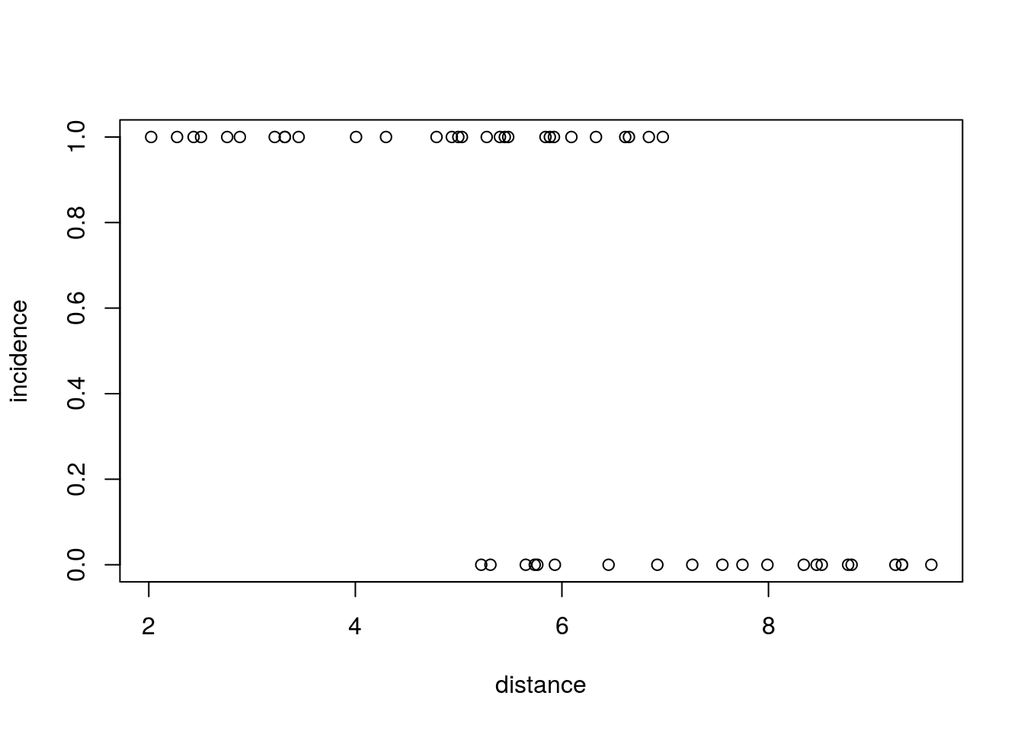

```r
plot(incidence ~ distance, data = isolation)
```

And, add the line. This time make the line blue with `col =`, dashed by changing the line type with `lty = 2`, and four times as wide with `lwd = 4`.

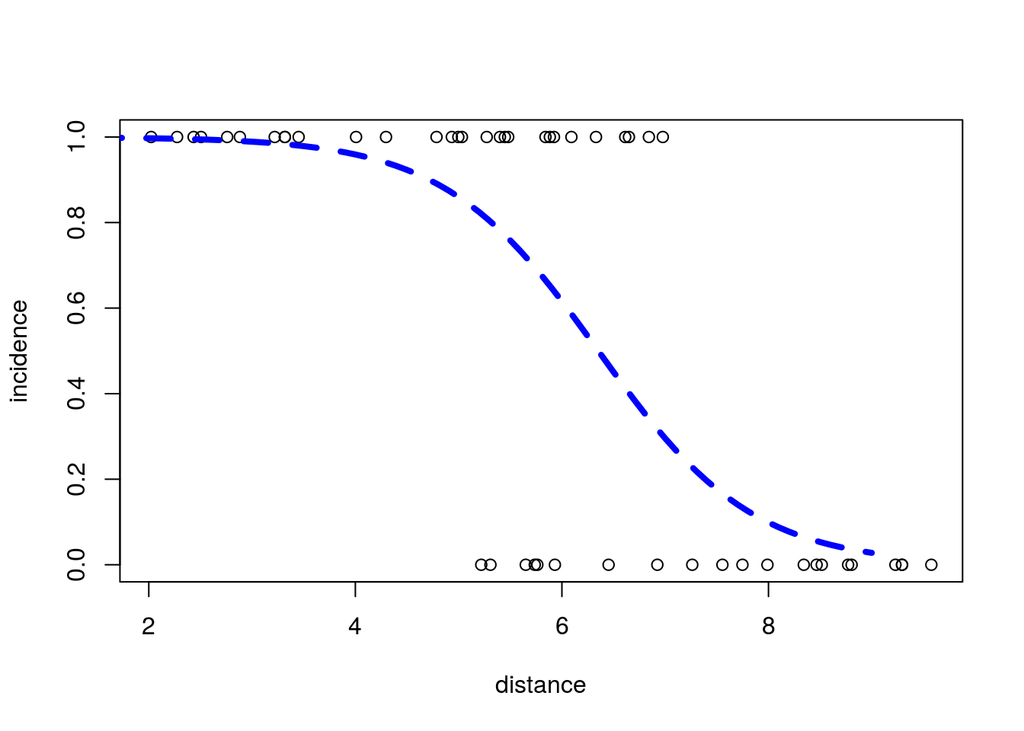

```r
plot(incidence ~ distance, data = isolation)
lines(xv, yv, col = 'blue', lty = 2, lwd = 4)
```

So far we have been predicting and plotting lines based solely on the values of a single predictor, using the models `ma` or `md`. What if we wanted to take area into account when we display the model for distance? We can go back to our additive model, `m0`.

To generate predicted values for distance accounting for area, we need to decide what values of area to use. A sensible option might be the mean of area (i.e., the mean size of island). We could then plot the fitted line showing how the effect of distance varies for an average-sized island. Calculate the mean size of island in the dataset.

```r
mean(isolation$area)
```

```
## [1] 4.31916
```

Now repeat this value to generate a vector the same length as our `xv` vector (the x-values of distance from which we predict incidence).

```r
rep(mean(isolation$area), times = length(xv))
```

```
##  [1] 4.31916 4.31916 4.31916 4.31916 4.31916 4.31916 4.31916 4.31916
##  [9] 4.31916 4.31916 4.31916 4.31916 4.31916 4.31916 4.31916 4.31916
## [17] 4.31916 4.31916 4.31916 4.31916 4.31916 4.31916 4.31916 4.31916
## [25] 4.31916 4.31916 4.31916 4.31916 4.31916 4.31916 4.31916 4.31916
## [33] 4.31916 4.31916 4.31916 4.31916 4.31916 4.31916 4.31916 4.31916
## [41] 4.31916 4.31916 4.31916 4.31916 4.31916 4.31916 4.31916 4.31916
## [49] 4.31916 4.31916 4.31916 4.31916 4.31916 4.31916 4.31916 4.31916
## [57] 4.31916 4.31916 4.31916 4.31916 4.31916 4.31916 4.31916 4.31916
## [65] 4.31916 4.31916 4.31916 4.31916 4.31916 4.31916 4.31916 4.31916
## [73] 4.31916 4.31916 4.31916 4.31916 4.31916 4.31916 4.31916 4.31916
## [81] 4.31916 4.31916 4.31916 4.31916 4.31916 4.31916 4.31916 4.31916
## [89] 4.31916 4.31916 4.31916
```

Ok, so now we have our values for distance (xv), and the vector of mean values of area (unnamed). To put both of these into the `predict()` function, we need to stick them in a dataframe. Make a data frame of our new values for area and distance. Call this dataframe `xv2`

```r
xv2 <- data.frame(area = rep(mean(isolation$area), times = length(xv)), distance = xv)
```

Now, put the model (m0), the new data (xv2), and the type of predicted values we want (‘response’), in a call to `predict(), and add these value to the datafram xv2, as a new column called`y`.

```r
xv2$y <- predict(m0, newdata = xv2, type = 'response')
```

Add this new line to the graph, referencing your x and y values in the xv2.

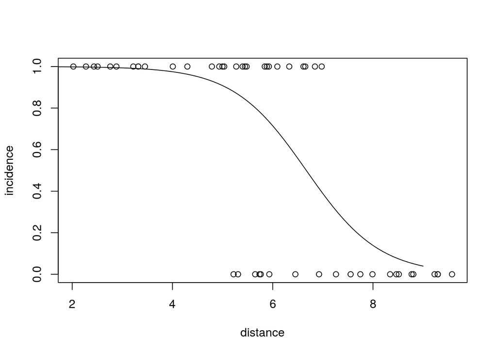

```r
plot(incidence ~ distance, data = isolation)
lines(xv2$distance, xv2$y)
```

# B. Group-level: Proportion data

At the group level, we look at the proportion of successes and failures (or female/male, short/tall, rep/dem, …) in groups or populations or sites, etc. In all these cases, we know both numbers—those of `successes` and those of `failures`, in contrast to Poisson regression (covered later) where we just have counts of `successes`.

In the past, the way proportion data was modelled was to use a single percentage as the response variable. However, this causes problems because: (i) The errors are not normally distributed, (ii) the variance is not constant, (iii) the response is bounded (by 1 above and by 0 below), and (iv) we lose information on the size of the sample, *n*, from which the proportion was estimated.

In the GLM framework, we can model proportion data directly. R carries out weighted regression, using the individual sample sizes as weights, and the logit link function to ensure linearity.

## Overdispersion

Overdispersion occurs in regression of proportion data when the residual deviance is larger than the residual degrees of freedom. There are two possibilities: either the model is misspecified, or the probability of success, *p*, is not constant within a given treatment level.

To deal with overdispersion, we can either respecify the model, or set `family = quasibinomial` rather than `family = binomial`.

## Fitting the model

As above, we use `glm()` with `family = 'binomial'`. In contrast to the binomial response, in the case of proportion data our response data is a matrix of two columns, one column of successes and one of failures. This matrix must be a single object (e.g., you could use `cbind()` to stick two columns together), which in most cases we will call `y`.

In this case, we have the number of males and females in a range of populations. Does sex ratio vary with population size? Look at the head of the `sexratio` data.

```r
head(sexratio)
```

```
##   total females males
## 1     1       1     0
## 2     4       3     1
## 3    10       7     3
## 4    22      18     4
## 5    55      22    33
## 6   121      41    80
```

First calculate the actual proportion of males in each population. Make a new column for this vector, called `$p`

```r
sexratio$p <- sexratio$males/(sexratio$males + sexratio$females)
```

To model proportion data, R requires a unique form of the response variable—a matrix of two columns of successes and failures, in this case males and females. Use `cbind()` to create such a variable, `y`.

```r
y <- cbind(sexratio$males, sexratio$females)
```

Now that we have the y variable, we can construct the model. We use `glm()` as before, setting y as the response, total as the predictor and `family = binomial`. Call it `m2`. A final point to consider is that to generate the predicted values, we need the column names in the original data and new data to match; yet another reason to use the formula approach with a `data =` argument.

```r
m2 <- glm(y ~ total, data = sexratio, family = binomial)
```

Look at the summary.

```r
summary(m2)
```

```
##
## Call:
## glm(formula = y ~ total, family = binomial, data = sexratio)
##
## Deviance Residuals:
##     Min       1Q   Median       3Q      Max
## -3.4619  -1.2760  -0.9911   0.5742   1.8795
##
## Coefficients:
##              Estimate Std. Error z value Pr(>|z|)
## (Intercept) 0.0807368  0.1550376   0.521    0.603
## total       0.0035101  0.0005116   6.862 6.81e-12 ***
## ---
## Signif. codes:  0 '***' 0.001 '**' 0.01 '*' 0.05 '.' 0.1 ' ' 1
##
## (Dispersion parameter for binomial family taken to be 1)
##
##     Null deviance: 71.159  on 7  degrees of freedom
## Residual deviance: 22.091  on 6  degrees of freedom
## AIC: 54.618
##
## Number of Fisher Scoring iterations: 4
```

The output is familar. For this continuous predictor, we get an intercept and slope, and the p-values indicate whether they are significantly different from 0. For categorical variables, we get, as usual, the base level mean, then differences between means. Furthermore, the coefficient estimates are in logits (*ln(p/(1 - p)*). To calculate a proportion (*p*) from a logit (x), you need to calculate `1/(1 + 1/(exp(x)))`.

However, we have substantial overdispersion (residual deviance = 22.091 is much greater than residual d.f. = 6). One reason for overdispersion is if the model is misspecified. Let’s try log(total) and see what happens. Try running a new model (called m3) with that.

```r
m3 <- glm(y ~ log(total), data = sexratio, family = binomial)
```

## Plotting proportion data

We can plot the proportion of males (`p`) as a function of the log(total) as normal, using `plot()`.

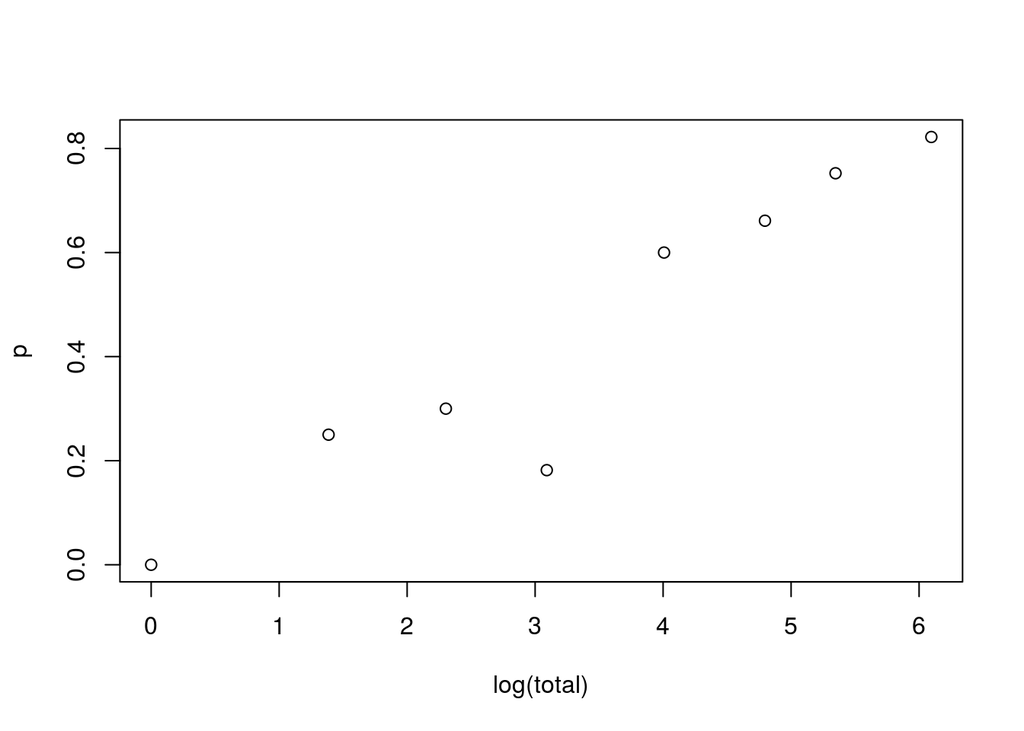

```r
plot(p ~ log(total), data = sexratio)
```

Now we need to generate the predicted values in order to plot the fitted line. First generate the x values (`xv`). Remember that we are working with log(total)—look at the x-axis of the plot— so we need values from 0 to 6, in steps of 0.1.

```r
xv <- seq(from = 0, to = 6, by = 0.1)
```

Now for the y values. Here we have to take the exponent of xv, because our model (m3) is of log(total), not log(log(total)). Call this new vector `yv` as before.

```r
yv <- predict(m3, data.frame(total = exp(xv)), type = "response")
```

Now add the fitted line to the plot, in red and twice the width.

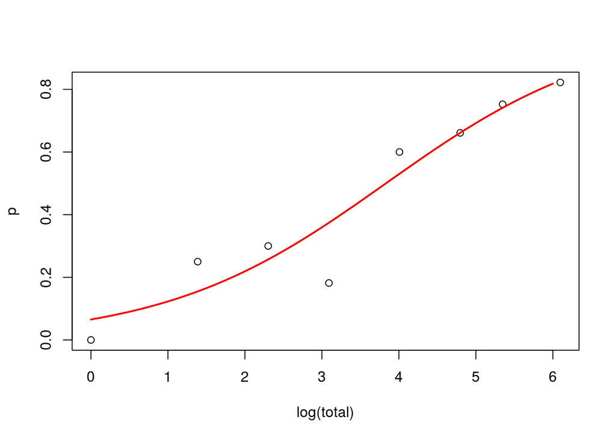

```r
plot(p ~ log(total), data = sexratio)
lines(xv, yv, col = 'red', lwd = 2)
```

Great! You should be able to analyse the two main types of binomial data now, and produce graphs of the data and fitted lines.

However, there are some kinds of proportion data that are better analysed differently:

*Percentage cover* data is best analysed using conventional linear models (assuming normal errors and constant variance) following arcsine transformation.

*Percentage change* in some continuous measurement (e.g., weight, tree diameter) is best modelled either as an ANCOVA of the final measurement with the initial measurement as a covariate, or by specifying the response as a relative change: log(final/initial), both of which should be linear models with normal errors.

Please submit the log of this lesson to Google Forms so that Simon may evaluate your progress.

1. Please, call me Humphrey.